# Notebook 13 – Solutions

## Getting Started

Before running this notebook, select “Session > Restart R and Clear Output” in the menu above to start a new R session. This will clear any old data sets and give us a blank slate to start with.

## What We Eat in America

```r
food <- read_csv("../data/wweia_food.csv.bz2")
food
```

```
## # A tibble: 173,174 × 15
##        id food_code day_of_week  time meal_name    food_source at_home grams
##     <dbl>     <dbl>       <dbl> <dbl> <chr>        <chr>       <chr>   <dbl>
##  1 109263  28320300           5    19 Dinner       Store - gr… Yes     200.
##  2 109263  91746110           5    18 Snack        Child/Adul… Yes      20
##  3 109263  58106210           5    12 Lunch        Child/Adul… No      238
##  4 109263  64104010           5    16 Snack        Store - gr… Yes     209
##  5 109263  11710801           5    19 Dinner       Store - gr… Yes     124
##  6 109263  54304020           5    14 Snack        Child/Adul… No       10
##  7 109263  57124200           5    16 Snack        Store - gr… Yes      11.7
##  8 109263  94000100           5     8 Extended co… <NA>        Yes     105
##  9 109263  11710801           5     8 Breakfast    Store - gr… Yes     130.
## 10 109263  94000100           5    14 Snack        <NA>        No      105
## # ℹ 173,164 more rows
## # ℹ 7 more variables: kcal <dbl>, protein <dbl>, carbs <dbl>, sugar <dbl>,
## #   fat <dbl>, caffeine <dbl>, alcohol <dbl>
```

We also have a dataset showing demographic information about each participant. The educational level is given as a coded number (more details when needed). The `ratio_to_poverty` variable indicates the ratio of the family household income to the poverty level. It’s truncated from above at 5; so values over 5 (households that make more than five times the poverty level) are pushed down to the value of 5.

```r
demo <- read_csv("../data/wweia_demo.csv.bz2")
demo
```

```
## # A tibble: 13,724 × 8
##        id   age gender edu_level race         family_status ratio_to_poverty
##     <dbl> <dbl> <chr>      <dbl> <chr>        <chr>                    <dbl>
##  1 109263     2 Male          NA Other        <NA>                      4.66
##  2 109264    13 Female        NA Mexican Ame… <NA>                      0.83
##  3 109265     2 Male          NA White        <NA>                      3.06
##  4 109266    29 Female         5 Other        Other                     5
##  5 109269     2 Male          NA Other Hispa… <NA>                      0.96
##  6 109270    11 Female        NA Black        <NA>                      1.88
##  7 109271    49 Male           2 White        Other                    NA
##  8 109272     0 Male          NA Mexican Ame… <NA>                      0.73
##  9 109273    36 Male           4 White        Other                     0.83
## 10 109274    68 Male           4 Missing      Other                     1.2
## # ℹ 13,714 more rows
## # ℹ 1 more variable: lang_interview <chr>
```

Finally, we also have a set of metadata about each of the food codes above. These give the specific food description, a less-granular category, and the least-granular food group. These can be joined with the key `food_code`.

```r
meta <- read_csv("../data/wweia_meta.csv.bz2")
meta
```

```
## # A tibble: 7,444 × 7
##    food_code food_code_description      category_number category_description
##        <dbl> <chr>                                <dbl> <chr>
##  1  11000000 Milk, human                           9602 Human milk
##  2  11100000 Milk, NFS                             1004 Milk, reduced fat
##  3  11111000 Milk, whole                           1002 Milk, whole
##  4  11111100 Milk, low sodium, whole               1002 Milk, whole
##  5  11111150 Milk, calcium fortified, …            1002 Milk, whole
##  6  11111160 Milk, calcium fortified, …            1006 Milk, lowfat
##  7  11111170 Milk, calcium fortified, …            1008 Milk, nonfat
##  8  11112110 Milk, reduced fat (2%)                1004 Milk, reduced fat
##  9  11112120 Milk, acidophilus, low fa…            1006 Milk, lowfat
## 10  11112130 Milk, acidophilus, reduce…            1004 Milk, reduced fat
## # ℹ 7,434 more rows
## # ℹ 3 more variables: meta_number <dbl>, meta_name <chr>, food_group <chr>
```

We will look at some of the main features today while introducing some new techniques that will help understand this data.

### Total Calories

Our data consists of a single day of eating patterns from each individual. Create a plot that shows the distribution (hint: `geom_density`) of the total number of calories that individuals in the dataset consumed on this day. You’ll see that a small number of individuals consumed a very large amount of calories. After creating the initial plot, try to remove some of the outliers to make the plot easier to read. Also, try to use some color to make the plot nicer to look at.

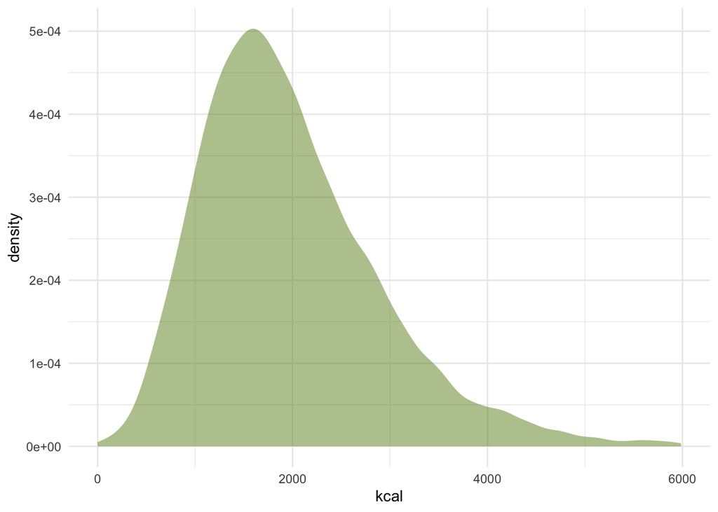

```r
# Question 01
food |>
  group_by(id) |>
  summarize(kcal = sum(kcal)) |>
  filter(kcal < 6000) |>
  ggplot(aes(kcal)) +
    geom_density(alpha = 0.5, fill = "olivedrab", color = NA)
```

We don’t have any information about the weight or activity level of each individual. We do, though, have a reported age and genders. Re-create your first plot, but this time show the distribution of the male and female participants. Note the similarities and differences between the two groups.

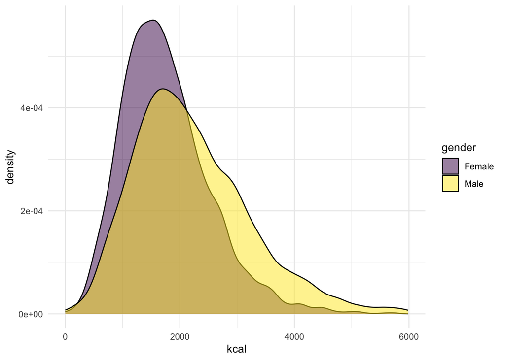

```r
# Question 02
food |>
  group_by(id) |>
  summarize(kcal = sum(kcal)) |>
  filter(kcal < 6000) |>
  left_join(demo, by = "id") |>
  ggplot(aes(kcal)) +
    geom_density(aes(fill = gender), alpha = 0.5) +
    scale_fill_viridis_d()
```

We also have the age of each participant. These are given in years and if we try to do the above plot for each individual year, things will get fairly messy. Perhaps a better way would be to group the ages together. We could do this manually with a bunch of `if_else` functions; another approach is to use a version of the `cut` function. If we include this line:

- `mutate(age = cut(age, breaks = seq(0, 80, by = 20), include.lowest = TRUE))`

In our pipe, it will change the continuous ages into concrete groups of 20 years each. Use this technique to show the distribution of calories by age group.

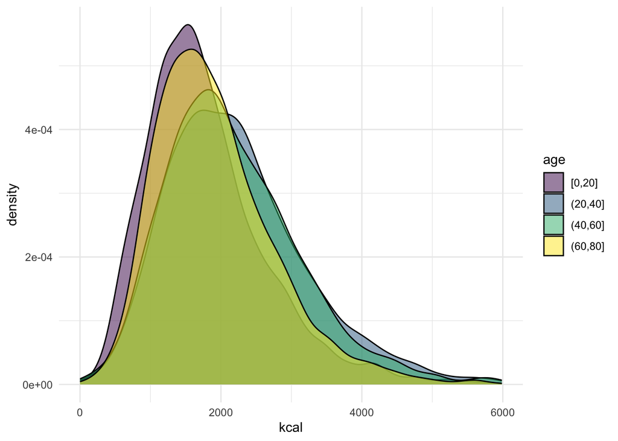

```r
# Question 03
food |>
  group_by(id) |>
  summarize(kcal = sum(kcal)) |>
  left_join(demo, by = "id") |>
  filter(kcal < 6000) |>
  mutate(age = cut(age, breaks = seq(0, 80, by = 20), include.lowest = TRUE)) |>
  ggplot(aes(kcal)) +
    geom_density(aes(fill = age), alpha = 0.5) +
    scale_fill_viridis_d()
```

The plot you just made should be somewhat readable, but it can be slightly hard to see each distribution on top of one another. One solution to this is to add the function `facet_wrap` to our plot. This function creates a number of small plots all at once broken out by a new variable. For example, the following will facet by our age variable:

- `facet_wrap(~age)`

Modify your previous plot in the block below using the facet wrap. Since this will make more space, split the ages into 10-year buckets in lieu of 20-year buckets.

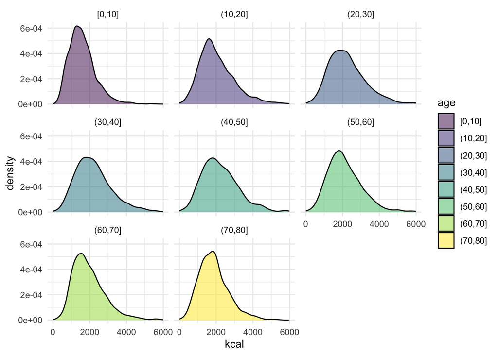

```r
# Question 04
food |>
  group_by(id) |>
  summarize(kcal = sum(kcal)) |>
  left_join(demo, by = "id") |>
  filter(kcal < 6000) |>
  mutate(age = cut(age, breaks = seq(0, 80, by = 10), include.lowest = TRUE)) |>
  ggplot(aes(kcal)) +
    geom_density(aes(fill = age), alpha = 0.5) +
    scale_fill_viridis_d() +
    facet_wrap(~age)
```

Now, with all of that added space, let’s add back the gender variable using the `fill` aesthetic. This will show the distribution of calories by age group and gender.

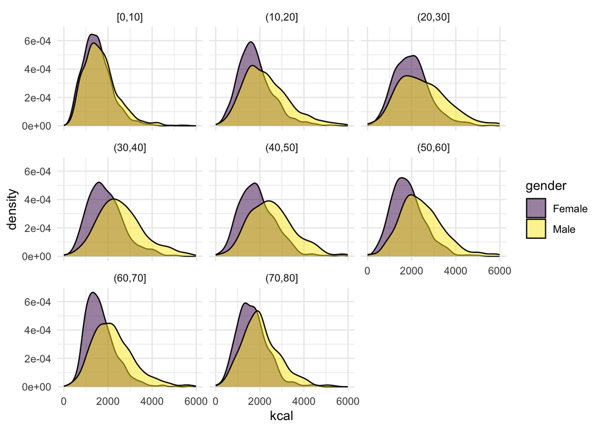

```r
# Question 05
food |>
  group_by(id) |>
  summarize(kcal = sum(kcal)) |>
  left_join(demo, by = "id") |>
  filter(kcal < 6000) |>
  mutate(age = cut(age, breaks = seq(0, 80, by = 10), include.lowest = TRUE)) |>
  ggplot(aes(kcal)) +
    geom_density(aes(fill = gender), alpha = 0.5) +
    scale_fill_viridis_d() +
    facet_wrap(~age)
```

### Meal Times

Create a bar plot showing time on the x-axis and the average number of calories eaten at each hour of the day. Use the function `factor` to convert the numeric time feature to a categorical feature; this will make the plot easier to read.

Make sure your plot is reasonable before you move it on. Your initial approach here will likely result in a subtle error that makes the plot look incorrect.

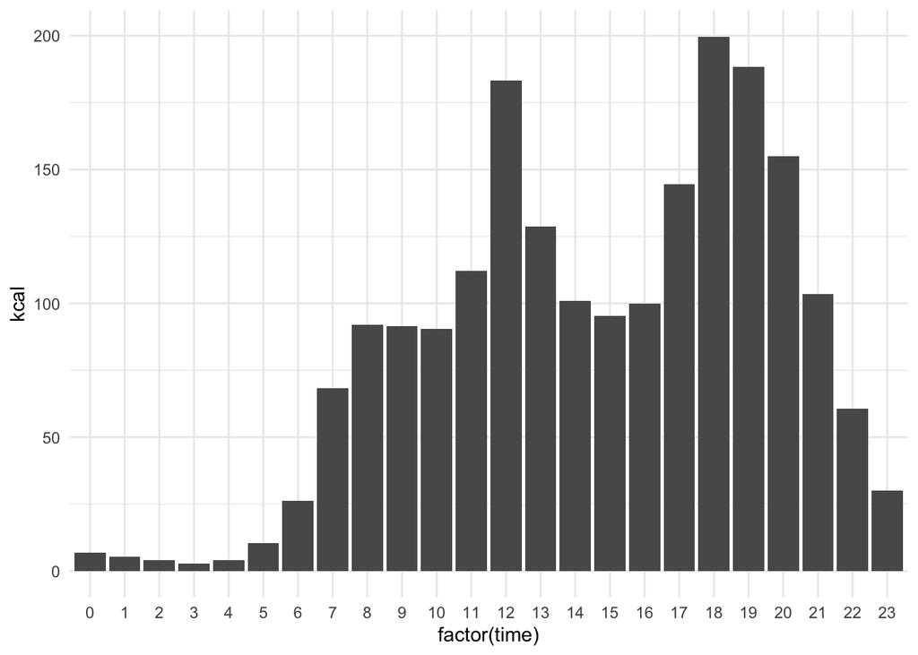

```r
# Question 06
# My guess is that most students will start by grouping by time and using the
# summarize  function with mean; that's not a bad first idea. However, it
# ignores anyone that has zero calories for that hour. As another option, you
# could divide by the number of rows in the demo table (`nrow(demo)`).
food |>
  mutate(total_people = n_distinct(id)) |>
  group_by(time) |>
  summarize(kcal = sum(kcal) / first(total_people)) |>
  ggplot(aes(factor(time), kcal)) +
    geom_col()
```

The data includes information about mealtime names. Filter the data to include only Breakfast, Lunch, and Dinner. Repeat the previous plot you had, but color the bars based on the name of the meal. You should see that the bar plot stacks the categories on top of one another.

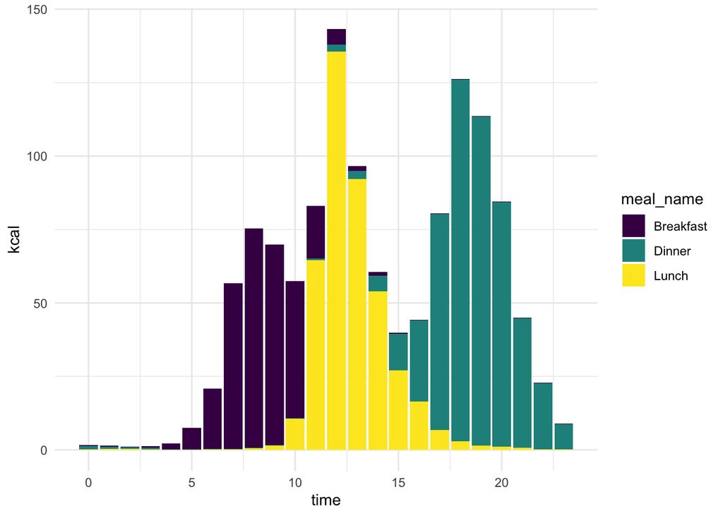

```r
# Question 07
food |>
  mutate(total_people = n_distinct(id)) |>
  group_by(time, meal_name) |>
  summarize(kcal = sum(kcal) / first(total_people)) |>
  filter(meal_name %in% c("Breakfast", "Lunch", "Dinner")) |>
  ggplot(aes(time, kcal, fill = meal_name)) +
    geom_col() +
    scale_fill_viridis_d()
```

The geometry `geom_col` has a parameter called `position` that we can set to describe how the intersecting bars, as above, are dealt with. The default is to stack the bars; we can change this by setting a different position. Below, remake your plot with `position = "dodge"` and note what happens.

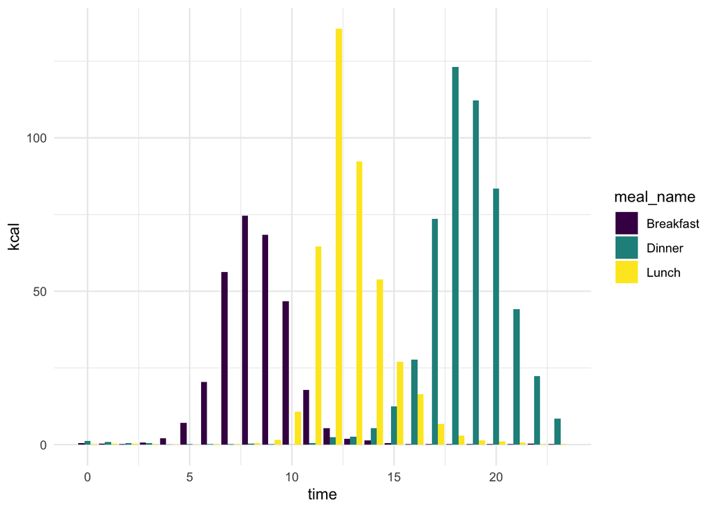

```r
# Question 08
food |>
  mutate(total_people = n_distinct(id)) |>
  filter(meal_name %in% c("Breakfast", "Lunch", "Dinner")) |>
  group_by(time, meal_name) |>
  summarize(kcal = sum(kcal) / first(total_people)) |>
  ggplot(aes(time, kcal, fill = meal_name)) +
    geom_col(position = "dodge") +
    scale_fill_viridis_d()
```

I think the dodge method looks better than the stack one in the above example. However, I think there is any even better option: setting the position to “identity”. This plots the bars right on top of one another, which are first seems like a terrible idea. However, if we also set `alpha = 0.7`, we can see the plot just as we did with the density plots in the previous section. Try this below:

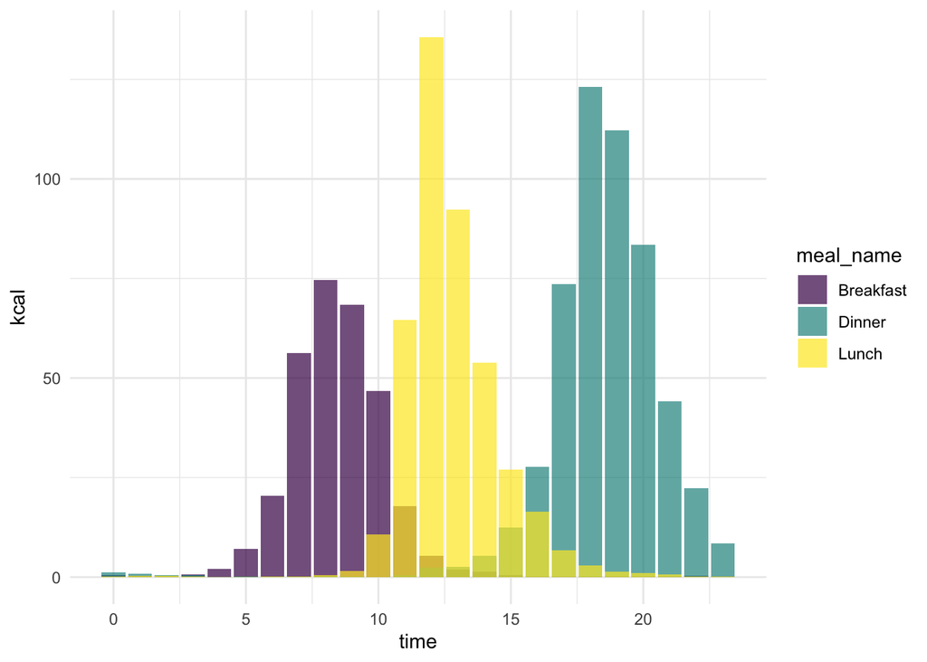

```r
# Question 09
food |>
  mutate(total_people = n_distinct(id)) |>
  filter(meal_name %in% c("Breakfast", "Lunch", "Dinner")) |>
  group_by(time, meal_name) |>
  summarize(kcal = sum(kcal) / first(total_people)) |>
  ggplot(aes(time, kcal, fill = meal_name)) +
    geom_col(position = "identity", alpha = 0.7) +
    scale_fill_viridis_d()
```

Can you see the distribution of the meals across the hours of the day? Are the what you might expect from your own meal times?

If you finish with the questions, above take a moment to consider the principles from our Data Feminism notes and how they might apply to this dataset. How are the ways that the data are organized making non-neutral decisions about what we can do with it? What are the consequences of not providing names or locations for the individuals? What are some possible negative ways that this data might be abused? What could be some ways we could use this information for social good. Note that while we have not looked at them yet, the data includes information about race, language, and income.